# Do Self Marked Emotional Moments Carry an EEG Signature? A Preregistered Reanalysis of the DENS Naturalistic Emotion Dataset

Author

Aditya Koundinya

## Abstract

Naturalistic film paradigms rarely reveal when an emotion is actually felt. The DENS dataset addresses this by recording self marked emotional moments (mouse clicks) during film viewing with 128 channel EEG. In this preregistered secondary analysis, implemented entirely in R, I compared 4 s epochs preceding clicks with unmarked epochs of the same clips (H1, posterior alpha) and related frontal alpha asymmetry to valence (H2) and frontal theta and global beta to arousal (H3a, H3b), using linear mixed models with false discovery rate correction. I found that 31 of 40 EEG files in the public release are truncated, so only 211 of 432 clip presentations could be analysed. After preprocessing, 451 epochs from 24 participants entered H1. Posterior alpha was lower before clicks than in control epochs (b = −0.121, 95% CI [−0.219, −0.023], d = −0.16, uncorrected p = .015), but the effect did not survive correction (adjusted p = .062), disappeared in an earlier window and was accompanied by a left lateralised sensorimotor alpha and beta decrease, which is consistent with preparation of the right hand click. Frontal asymmetry was unrelated to valence, and theta and beta were unrelated to arousal (adjusted p = .789, = .433 and = .433). These results provide no confirmatory evidence that self marked emotional moments carry a distinct spectral signature, and they show that click based emotion markers require control periods matched for motor output.

**Index Terms:** Electroencephalography, emotion, naturalistic stimuli, alpha oscillations, frontal alpha asymmetry, mixed models, preregistration, open data.

# 1 Introduction

Laboratory studies of emotion and the electroencephalogram (EEG) have mostly relied on brief, repeated, context free stimuli such as affective pictures. Naturalistic stimuli such as film clips provide context and unfold over time, and they are increasingly recommended for studying emotion as it is experienced [1], [2]. Their cost is temporal uncertainty. Across a minute of film, a viewer feels an emotion only at certain moments, and averaging over the whole clip mixes those moments with periods of neutral viewing or mind wandering. Widely used affective EEG datasets such as DEAP provide a single rating per clip and no information about when the emotion was felt [3].

The Dataset on Emotion with Naturalistic Stimuli (DENS) addresses this limitation directly [4], [5]. While 128 channel EEG was recorded, participants watched one minute film clips, clicked a mouse whenever they felt a discernible emotion, rated each clip on valence, arousal and further scales, and labelled each click with an emotion category. The dataset authors have used these “emotional events” to decode valence and arousal [6] and to describe theta and beta dynamics [7]. To my knowledge, no preregistered, hypothesis driven test of classic spectral markers around these self marked moments has been reported.

Three lines of prior work motivate specific predictions. First, alpha power (8 to 13 Hz) decreases when attention is engaged and sensory regions are in an active processing state [8], [9]. Emotionally arousing pictures produce stronger posterior alpha desynchronization than neutral pictures [10], [11], and shared EEG responses to film have been linked to emotionally laden attention [12]. A felt emotional moment should therefore show lower posterior alpha than other periods of the same film (H1). Second, frontal alpha asymmetry (FAA) has been related to approach and withdrawal motivation and, less consistently, to valence: relatively greater left frontal activity, that is, less left alpha, accompanies approach related and positive states [13], [14], [15]. FAA during marked moments should therefore increase with the clip’s rated valence (H2). Third, theta and beta activity have been associated with emotional processing and arousal [16], [17], [18], so frontal theta (H3a) and global beta (H3b) during marked moments should increase with rated arousal.

The contributions of this paper are as follows.

1. I report an audit of the public DENS release (OpenNeuro ds003751, version 1.0.6) showing that most EEG binaries are truncated, and I document how the remaining data can be used.
2. I provide a preregistered test of four hypotheses linking self marked emotional moments to EEG spectral activity and to self reported valence and arousal.
3. I show that the only effect approaching significance is better explained by motor preparation than by emotion, which identifies a design constraint for click based emotion markers.
4. I release a complete, reproducible R pipeline, from raw EEGLAB files to the rendered paper.

# 2 Materials and Methods

## 2.1 Dataset and Data Audit

I used OpenNeuro ds003751 version 1.0.6 [5], downloaded from the public OpenNeuro S3 bucket (5.06 GB). I identified the version through the DataLad mirror of the dataset, whose git annex checksums matched every EEG file I downloaded. The dataset contains EEG for 40 participants (the dataset paper reports 43 recorded participants, 3 of whom were excluded for movement [4]). The participants file lists 54 unique identifiers, 14 of them without data, which explains the conflicting participant counts found in secondary sources. Ratings files exist for 34 participants. EEG was recorded with a 128 channel EGI HydroCel net referenced to the vertex (Cz, E129) at 250 Hz, together with one ECG lead. Participants watched 9 to 11 clips of about 60 s (emotional clips plus two neutral clips) and were instructed to click “only when they felt any discernible emotion” [4]. After each clip they rated valence, arousal and dominance (1 to 9), liking, familiarity and relevance, and they assigned an emotion category and an intensity to each click. Thirty of 34 participants reported clicking 2 to 3 s after becoming aware of the emotion [4]. I verified that event onsets in the BIDS events files are stored in samples rather than seconds by comparing them with the click times in the ratings files.

During the audit I found that for 31 of 40 participants the binary file holding the samples is shorter than its header implies. The checksums show that this is the published state of version 1.0.6 rather than a download error. Because EEGLAB stores samples interleaved across channels, a truncated file contains complete data for an initial part of the session. I therefore used every clip whose full window lay inside the recorded samples: 211 of 432 clip presentations and 261 of 744 clicks. Only 9 participants have complete recordings.

## 2.2 Preregistration

Before computing any outcome measure, I committed the hypotheses, epoch definitions, preprocessing parameters, exclusion rules, statistical models, correction method and the split between confirmatory and exploratory analyses to the project repository, under the commit message “Preregistration, locked before analysis”. Up to that point I had examined only metadata, file headers and a quality control pilot of the preprocessing in two participants, without epochs, conditions or ratings. Every later change is listed as a deviation in Appendix A.

## 2.3 Epoch Definition

Times are given relative to clip onset, and the usable span of a clip runs from 2 s after onset to 0.5 s before its end. A marked epoch spans 4.5 s to 0.5 s before a click. This centres the 4 s window on the reported felt moment and ends it before the hand movement. A click was used only if no other click occurred in the preceding 5 s. Control epochs are consecutive, nonoverlapping 4 s windows of the same clip outside the zone from 7 s before to 3 s after every click. For the condition contrast, only clips with at least one retained marked epoch and one retained control epoch contribute. A second marked window, from 6.5 s to 2.5 s before the click, served as a preregistered robustness check against motor preparation [19].

## 2.4 Preprocessing

ICA used FastICA [21] with 70 components after principal component reduction, trained on clean 1 s windows. Because ICLabel [22] is not available in R, I classified components with fixed rules applied identically to every participant. A component was labelled ocular if its absolute correlation with a vertical or horizontal EOG derivation built from periocular channels was at least 0.7, or if that correlation had a z score of at least 3 across components and an absolute value of at least 0.3. It was labelled muscular if its 20 to 40 Hz power was at least as large as its 2 to 20 Hz power [23] and its topography was focal (at least 40 % of the squared weights on one channel) or peripheral (at least 50 % on face and neck channels). It was labelled cardiac if its correlation with the ECG was at least 0.5. A flagged component was removed only if removing it did not increase the typical amplitude of clean data. A simulation confirmed that the implementation recovers and removes a known source.

The preregistered amplitude rule rejected an epoch if any of the 91 scalp channels outside the face and neck ring exceeded 100 µV. Because sporadic single channel transients caused this rule to discard nearly all data, I used epoch level channel repair instead. In each epoch, up to 9 scalp channels exceeding 100 µV were replaced by spherical spline interpolation, and the epoch was kept if no scalp channel then exceeded 100 µV. Epochs with more flagged channels were rejected. I report the preregistered rule as a robustness analysis.

## 2.5 Spectral Features

I estimated power spectra per epoch with Welch’s method [24] (2 s Hann windows, 50 % overlap, 0.5 Hz resolution). Band power in the theta (4 to 8 Hz), alpha (8 to 13 Hz) and beta (13 to 30 Hz) bands was averaged over the channels of predefined regions, each consisting of anchor sites equivalent to the 10/20 system plus all scalp channels within 3 cm, and then log transformed. Posterior alpha used 19 parieto occipital channels, frontal theta used 14 frontal channels and global beta used all 91 scalp channels. FAA was computed as ln(alpha, right F4 cluster) minus ln(alpha, left F3 cluster), with 6 mirror symmetric channels per cluster [25]. For the exploratory analysis, heart rate was derived from ECG R peaks.

## 2.6 Statistical Analysis

I fitted linear mixed models with lme4 and lmerTest, using restricted maximum likelihood and Satterthwaite degrees of freedom [26], [27]. The H1 model predicted epoch level ln posterior alpha from condition (control 0, marked 1), with a random slope for condition per participant and random intercepts for participant, stimulus and clip presentation. The H2, H3a and H3b models predicted FAA, ln frontal theta and ln global beta in marked epochs from the standardised clip rating (valence for H2, arousal for H3), with a random slope per participant and the same intercepts. Random effects followed a preregistered simplification rule when a model did not converge or was singular [28]. Effect sizes are d for H1, scaled by the summed random intercept and residual variances [29], and standardised slopes for H2 and H3. The four confirmatory p values were corrected with the Benjamini and Hochberg procedure [30] at q = .05. The robustness analyses (alternative 0.5 Hz highpass, 75 µV threshold, exclusion of outlier participants, the early marked window, complete recordings only, intercept only random effects and the preregistered rejection rule) are descriptive. Exploratory analyses are corrected within their own families.

# 3 Results

## 3.1 Data Retained

Of 40 participants, 7 had no complete clip in the recorded data and 3 exceeded the preregistered limit of 25 bad channels. No participant failed in processing, which left 30 participants with features (Fig. 1). The median number of interpolated channels was 7.5, ICA removed a median of 3.5 of 70 components, and cleaning left alpha power at a median of 0.94 times its value before cleaning. Of 198 marked and 2036 control epochs, I retained 89 and 979 (the preregistered rule without channel repair would have retained 30 and 381), and 62 % of retained epochs had at least one repaired channel. The H1 model contained 451 epochs from 53 clip presentations of 24 participants, and the H2 and H3 models contained 70 marked epochs from 21 participants with ratings. Rated valence and arousal spanned the full scales (Fig. 2).

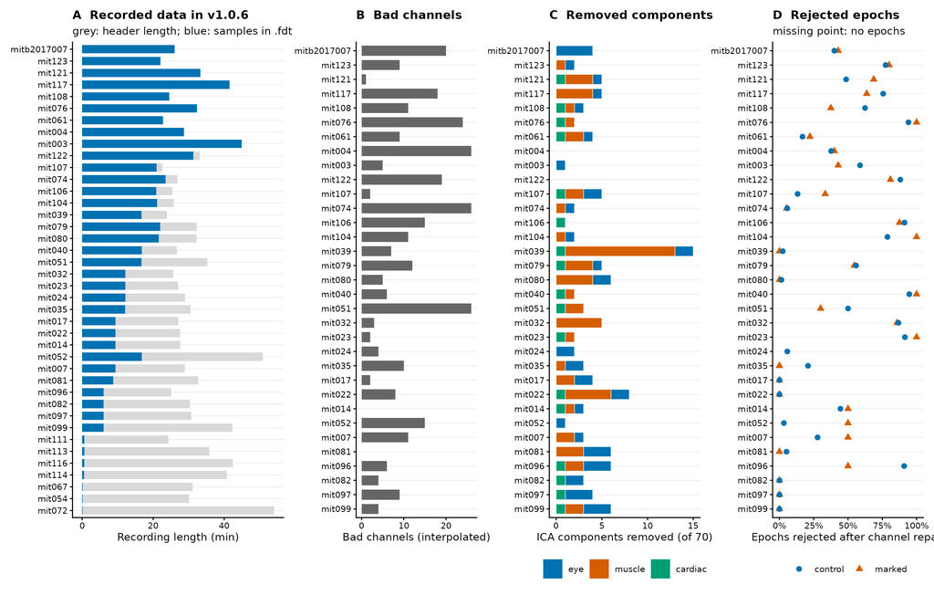

Fig. 1: Data availability and quality control per participant. (a) Recording length in the file header (grey) and samples present in the version 1.0.6 files (blue). (b) Interpolated channels. (c) Removed ICA components. (d) Epochs rejected after channel repair.

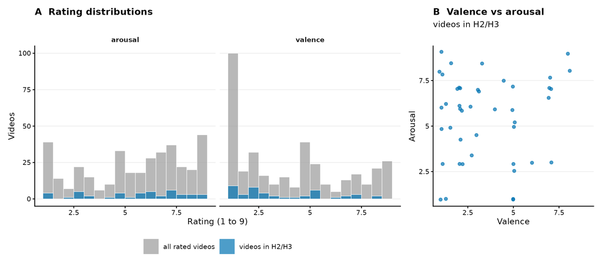

Fig. 2: Valence and arousal ratings of all rated clips and of the clips that entered H2 and H3.

## 3.2 Confirmatory Tests

Confirmatory Mixed Models. H1: posterior alpha, marked versus control; H2: FAA and valence; H3a: frontal theta and arousal; H3b: global beta and arousal. Std: d for H1, standardised slope for H2 and H3. N: epochs/participants.

| H | b | 95% CI | df | p | p (FDR) | Std | N | Random effects |
| --- | --- | --- | --- | --- | --- | --- | --- | --- |
| H1 | −0.121 | [−0.219, −0.023] | 411.9 | 0.015 | 0.062 | −0.16 | 451/24 | intercept |
| H2 | −0.015 | [−0.123, 0.094] | 66.5 | 0.789 | 0.789 | −0.03 | 70/21 | minimal |
| H3a | −0.063 | [−0.190, 0.064] | 67.6 | 0.324 | 0.433 | −0.11 | 70/21 | minimal |
| H3b | 0.061 | [−0.067, 0.190] | 12.8 | 0.323 | 0.433 | 0.16 | 70/21 | full |

Table I summarises the confirmatory models. Posterior alpha power was lower in marked than in control epochs, b = −0.121, 95% CI [−0.219, −0.023], t(411.9) = −2.43, p = .015, d = −0.16 (Fig. 3). After Benjamini and Hochberg correction across the four confirmatory tests, the effect was not significant (adjusted p = .062), so H1 is not supported at the preregistered criterion. FAA in marked epochs was not related to valence, b = −0.015, 95% CI [−0.123, 0.094], t(66.5) = −0.27, p = .789, with a standardised slope of −0.03. Frontal theta was not related to arousal, b = −0.063, 95% CI [−0.190, 0.064], t(67.6) = −0.99, p = .324, and neither was global beta, b = 0.061, 95% CI [−0.067, 0.190], t(12.8) = 1.03, p = .323 (Fig. 5). None of the four hypotheses was therefore supported. The confidence intervals for H2 and H3 exclude standardised slopes larger than about 0.5 SD per SD of rating.

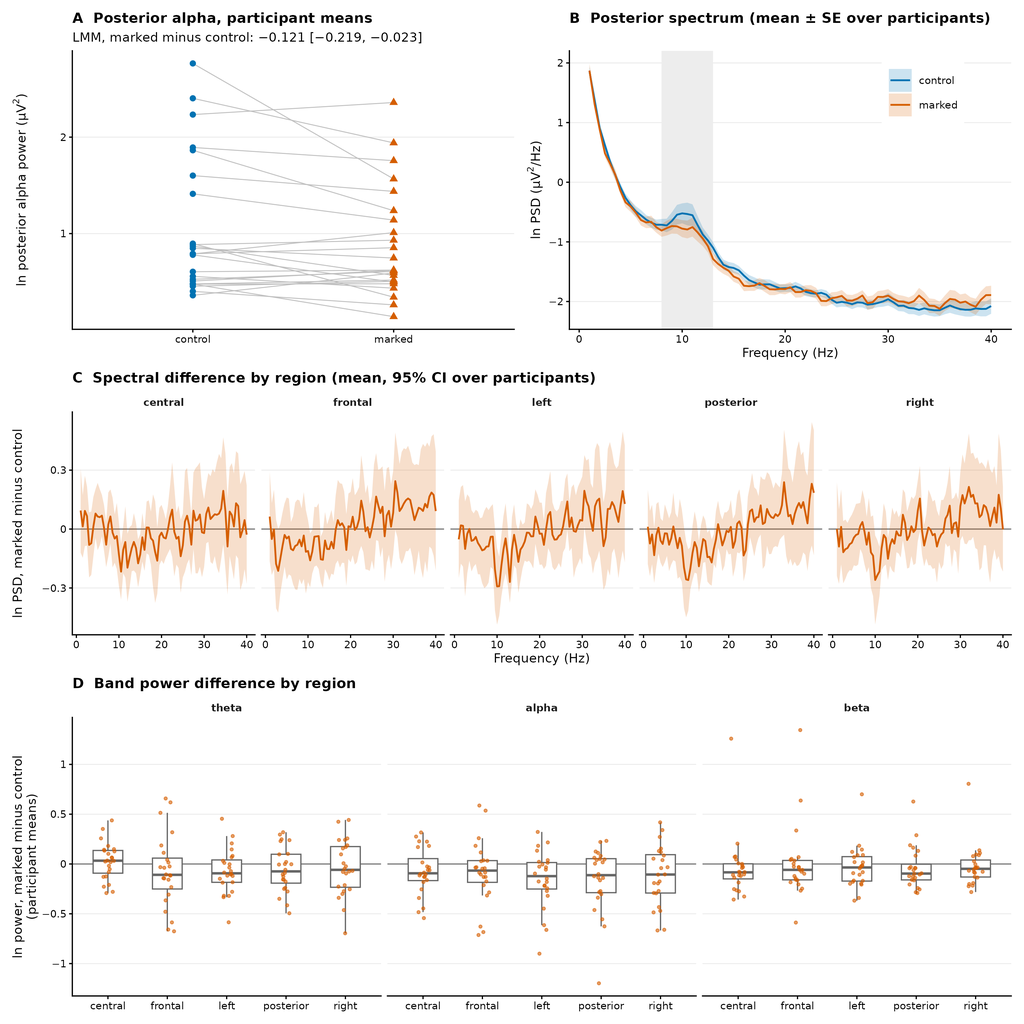

Fig. 3: Band power by condition in the H1 analysis set. (a) Participant mean ln posterior alpha. (b) Posterior spectra. (c) Marked minus control spectra by region. (d) Marked minus control band power per participant.

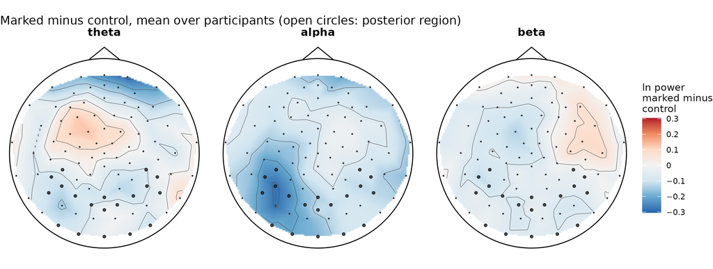

Fig. 4: Topographies of the marked minus control difference in ln band power, averaged over participants (exploratory, uncorrected). Nose up; left hemisphere on the left.

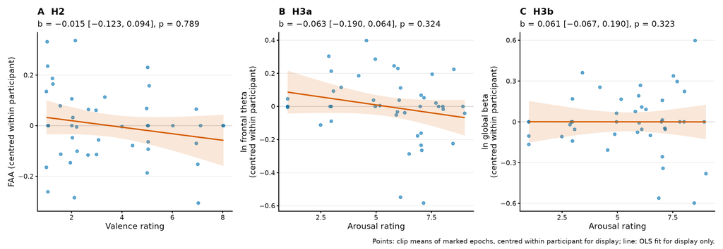

Fig. 5: Marked epoch measures against clip ratings for H2, H3a and H3b, shown as clip means centred within participant. Statistics are from the mixed models.

## 3.3 Robustness

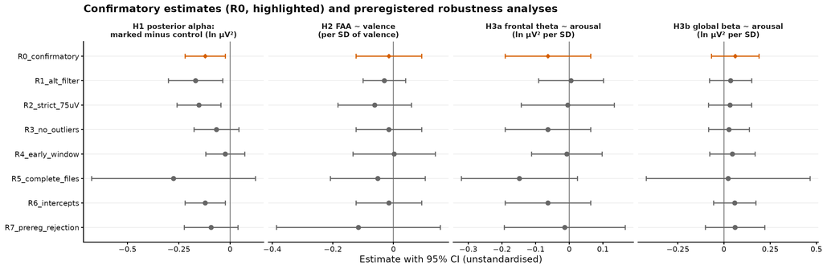

Fig. 6: Confirmatory estimates (orange) and preregistered robustness analyses with 95 % confidence intervals. R7 applies the preregistered epoch rejection rule without channel repair.

Model diagnostics showed approximately normal random effects, whereas the H1 residuals were right skewed and heavy tailed (skewness 0.66, excess kurtosis 3.07). Fixed effect estimates of linear mixed models are fairly robust to such departures, and the H1 conclusion was unchanged under outlier exclusion. Because the selected random structures dropped the random slope (H1) and the clip presentation intercept (H2, H3a), I also ran two conservative checks: a paired t test on participant means for H1 (b = −0.155, 95% CI [−0.290, −0.019], t(23), p = .027, 24 participants), and models of clip level means of marked epochs for H2, H3a and H3b (p = .537, = .157 and = .339). Both agree with the confirmatory results.

## 3.4 Exploratory Analyses

Among the condition effects per band and region, alpha was lower in marked epochs over the left lateral region (b = −0.148, 95% CI [−0.239, −0.057], FDR adjusted p = .023). This was the only one of 15 band and region contrasts that survived correction within its family; theta and beta showed no condition effects (all adjusted p = .426 or larger). The alpha decrease was centred over left centroparietal sites (Fig. 4).

None of the 30 band and region associations with valence or arousal in marked epochs (smallest adjusted p = .986) and none of the 8 associations between the clip level marked minus control difference and the ratings (smallest adjusted p = .711) was significant.

Heart rate in marked epochs did not differ reliably from control epochs (b = −1.00, 95% CI [−2.05, 0.05] bpm, p = .063). Around clicks, heart rate decreased before the click (lowest −0.96 bpm relative to baseline at −1 s) and rose briefly afterwards (highest 0.99 bpm at 3 s; Fig. 7), with wide confidence intervals. The mean change from 0 to 5 s after the click relative to baseline was 0.02 bpm (95 % CI [−0.79, 0.82], 29 participants).

Click intensity was not related to posterior alpha in marked epochs (b = 0.054, 95% CI [−0.028, 0.136], p = .195). Control epochs of neutral clips had higher posterior alpha than control epochs of emotional clips (b = 0.168, 95% CI [0.028, 0.308], p = .025; uncorrected single test).

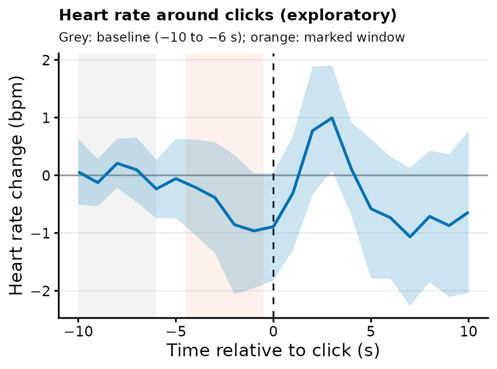

Fig. 7: Heart rate change around clicks (exploratory); mean and 95 % confidence interval over participants.

## 3.5 Post Hoc Analysis of Motor Preparation

Because the H1 effect disappeared in the earlier window and peaked over the left hemisphere, I tested whether it reflects preparation of the right hand mouse click, which desynchronises mu (alpha band) and beta activity over the contralateral sensorimotor cortex [19]. This analysis was not preregistered. In the preregistered marked window, alpha decreased over the left sensorimotor cluster around C3 (b = −0.116, 95% CI [−0.218, −0.014], p = .025) but not over the right cluster around C4 (b = −0.002, 95% CI [−0.107, 0.103]). Right minus left lateralisation therefore increased for alpha (b = 0.113, 95% CI [0.017, 0.209], p = .021) and beta (b = 0.102, 95% CI [0.028, 0.177], p = .007). In the early window these effects were smaller and not significant (alpha lateralisation b = 0.043, 95% CI [−0.059, 0.146], beta b = 0.058, 95% CI [−0.016, 0.132]). I chose these tests after seeing the confirmatory results, and they are uncorrected.